# Group277_BreastCancerDataset

## Assignment Details

**Dataset Name - Breast Cancer Dataset** We're working on Breast Cancer Dataset. And below is the team details:

Name: SHIVAM SAHIL

- Group: 277

### Team Member Names with Roll Numbers -

VIJAYA KUMAR S - 2023aa05034

SHIVAM SAHIL - 2023aa05663

JAIDEEP SINGH SACHDEV - 2023aa05196

VENAKTESH SABINKAR - 2023aa05510

1. Import Libraries/Dataset a. Download the dataset b. Import the required libraries

```python
# Basic libraries for data manipulation and array handling
import pandas as pd
import numpy as np

# Visualization libraries
import matplotlib.pyplot as plt
import seaborn as sns

# Preprocessing and model selection libraries
from sklearn.model_selection import train_test_split
from sklearn.preprocessing import StandardScaler, MinMaxScaler

# Model building libraries
from sklearn.linear_model import LogisticRegression
from sklearn.tree import DecisionTreeClassifier

# Performance evaluation libraries
from sklearn.metrics import confusion_matrix, log_loss, classification_report

# Model Training
from sklearn.neighbors import KNeighborsClassifier
from sklearn.metrics import accuracy_score, precision_recall_fscore_support
from sklearn.ensemble import RandomForestClassifier
from sklearn.model_selection import GridSearchCV
from sklearn.naive_bayes import GaussianNB
from sklearn.ensemble import AdaBoostClassifier




# Load the dataset
dataset_path = r'ml_assignment_ds.csv'
data = pd.read_csv(dataset_path)
```

## 2. Data Visualization and Exploration

a. Print at least 5 rows for sanity check to identify all the features present in the dataset and if the target matches with them. b. Print the description and shape of the dataset. c. Provide appropriate visualization to get an insight about the dataset. d. Try exploring the data and see what insights can be drawn from the dataset.

```python
# Print the first 5 rows of the dataset
data.head()
```

|  | Sample code number | Clump Thickness | Uniformity of Cell Size | Uniformity of Cell Shape | Marginal Adhesion | Single Epithelial Cell Size | Bare Nuclei | Bland Chromatin | Normal Nucleoli | Mitoses | Class |
| --- | --- | --- | --- | --- | --- | --- | --- | --- | --- | --- | --- |
| 0 | 1000025 | 5 | 1 | 1 | 1 | 2 | 1 | 3 | 1 | 1 | 2 |
| 1 | 1002945 | 5 | 4 | 4 | 5 | 7 | 10 | 3 | 2 | 1 | 2 |
| 2 | 1015425 | 3 | 1 | 1 | 1 | 2 | 2 | 3 | 1 | 1 | 2 |
| 3 | 1016277 | 6 | 8 | 8 | 1 | 3 | 4 | 3 | 7 | 1 | 2 |
| 4 | 1017023 | 4 | 1 | 1 | 3 | 2 | 1 | 3 | 1 | 1 | 2 |

```python
# Print description and shape
data.describe()
```

|  | Sample code number | Clump Thickness | Uniformity of Cell Size | Uniformity of Cell Shape | Marginal Adhesion | Single Epithelial Cell Size | Bland Chromatin | Normal Nucleoli | Mitoses | Class |
| --- | --- | --- | --- | --- | --- | --- | --- | --- | --- | --- |
| count | 6.990000e+02 | 699.000000 | 699.000000 | 699.000000 | 699.000000 | 699.000000 | 699.000000 | 699.000000 | 699.000000 | 699.000000 |
| mean | 1.071704e+06 | 4.417740 | 3.134478 | 3.207439 | 2.806867 | 3.216023 | 3.437768 | 2.866953 | 1.589413 | 2.689557 |
| std | 6.170957e+05 | 2.815741 | 3.051459 | 2.971913 | 2.855379 | 2.214300 | 2.438364 | 3.053634 | 1.715078 | 0.951273 |
| min | 6.163400e+04 | 1.000000 | 1.000000 | 1.000000 | 1.000000 | 1.000000 | 1.000000 | 1.000000 | 1.000000 | 2.000000 |
| 25% | 8.706885e+05 | 2.000000 | 1.000000 | 1.000000 | 1.000000 | 2.000000 | 2.000000 | 1.000000 | 1.000000 | 2.000000 |
| 50% | 1.171710e+06 | 4.000000 | 1.000000 | 1.000000 | 1.000000 | 2.000000 | 3.000000 | 1.000000 | 1.000000 | 2.000000 |
| 75% | 1.238298e+06 | 6.000000 | 5.000000 | 5.000000 | 4.000000 | 4.000000 | 5.000000 | 4.000000 | 1.000000 | 4.000000 |
| max | 1.345435e+07 | 10.000000 | 10.000000 | 10.000000 | 10.000000 | 10.000000 | 10.000000 | 10.000000 | 10.000000 | 4.000000 |

```python
data.shape
```

```
(699, 11)
```

### Appropriate Visualization to get an insight about the dataset

As we can see, the dataset consists of several columns related to cell characteristics, which are likely from a study on cell morphology for cancer detection. The columns are as follows:

- Sample code number: ID number.
- Clump Thickness: Clump thickness of the cells.
- Uniformity of Cell Size: Uniformity of cell size.
- Uniformity of Cell Shape: Uniformity of cell shape.
- Marginal Adhesion: Marginal adhesion of the cells.
- Single Epithelial Cell Size: Size of the single epithelial cell.
- Bare Nuclei: Bare nuclei.
- Bland Chromatin: Bland chromatin.
- Normal Nucleoli: Normal nucleoli.
- Mitoses: Mitoses.
- Class: The classification outcome.

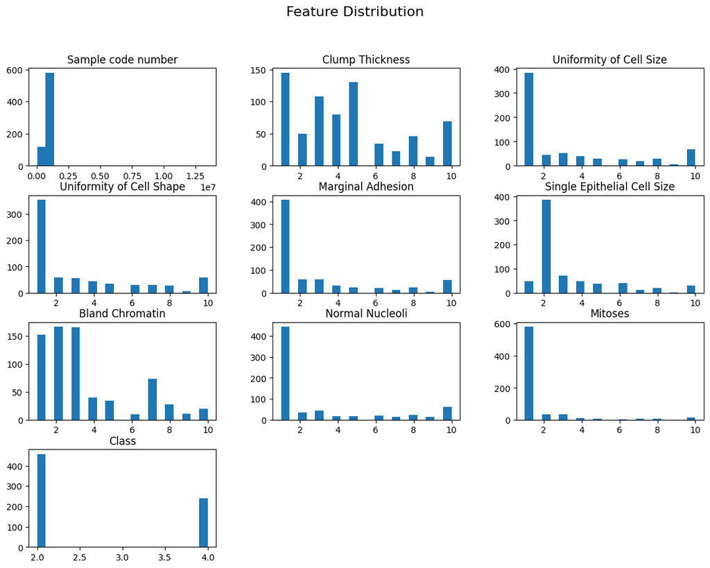

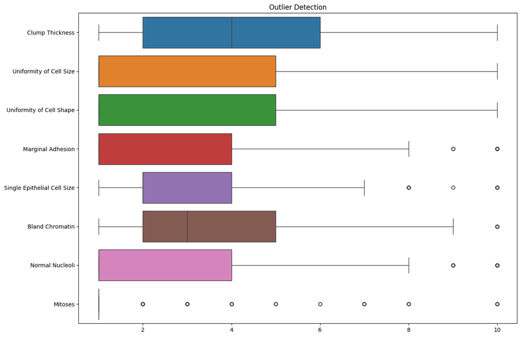

```python
# Histograms for feature distribution
data.hist(bins=20, figsize=(14,10), grid=False)
plt.suptitle("Feature Distribution", fontsize=16)
plt.show()

# Boxplot for outlier detection
plt.figure(figsize=(14,10))
sns.boxplot(data=data.drop(["Sample code number", "Class"], axis=1), orient="h")
plt.title("Outlier Detection")
plt.show()
```

```python
# Correlation matrix
plt.figure(figsize=(12, 10))
sns.heatmap(data.drop(["Sample code number"], axis=1).corr(), annot=True, fmt=".2f", cmap='coolwarm')
plt.title("Correlation Matrix")
plt.show()
```

[output not shown]

Since we're having error `ValueError: could not convert string to float: '?'` which indicates we need to do some data cleaning before we can proceed with the analysis.

Let's remove `?` with the median in order to avoid skewness.

```python
# First determine the columns which have `?`  or nan values in it
print('First determine the columns which have `?`  or nan values in it')
print(data.isin(['?', np.nan, None]).sum())
# Checking for empty cells
print('Checking for empty cells')
print(data.isnull().sum())
```

```
First determine the columns which have `?`  or nan values in it
Sample code number              0
Clump Thickness                 0
Uniformity of Cell Size         0
Uniformity of Cell Shape        0
Marginal Adhesion               0
Single Epithelial Cell Size     0
Bare Nuclei                    16
Bland Chromatin                 0
Normal Nucleoli                 0
Mitoses                         0
Class                           0
dtype: int64
Checking for empty cells
Sample code number             0
Clump Thickness                0
Uniformity of Cell Size        0
Uniformity of Cell Shape       0
Marginal Adhesion              0
Single Epithelial Cell Size    0
Bare Nuclei                    0
Bland Chromatin                0
Normal Nucleoli                0
Mitoses                        0
Class                          0
dtype: int64
```

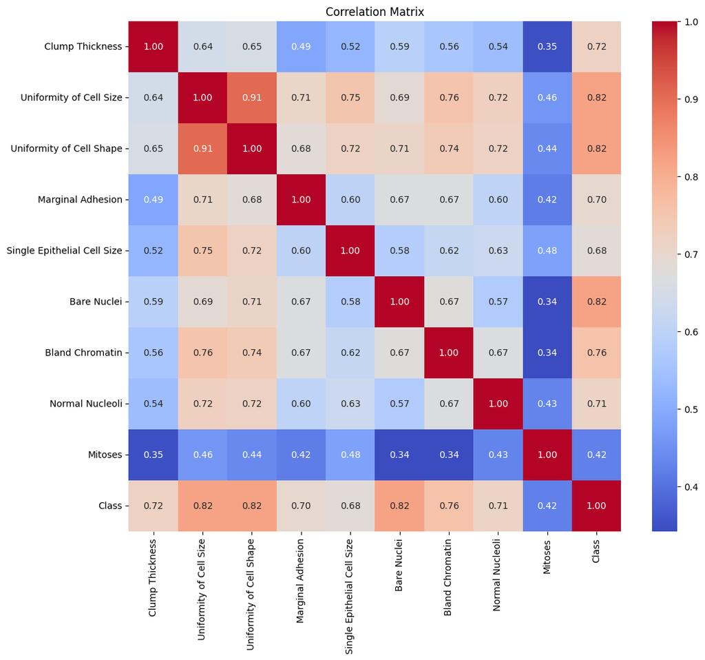

```
Target class balance:
 Class
2    0.655222
4    0.344778
Name: proportion, dtype: float64
```

```python
# Remove ? by the median value in the given column
data['Bare Nuclei'] = data['Bare Nuclei'].replace('?', np.nan)
# Convert the column to numeric
data['Bare Nuclei'] = pd.to_numeric(data['Bare Nuclei'])
# The median is usually preferred to other measures of central tendency when data set is skewed
data['Bare Nuclei'] = data['Bare Nuclei'].fillna(data['Bare Nuclei'].median())

# Now Plot the correlation matrix again
plt.figure(figsize=(12, 10))
sns.heatmap(data.drop(["Sample code number"], axis=1).corr(), annot=True, fmt=".2f", cmap='coolwarm')
plt.title("Correlation Matrix")
plt.show()

# Print Target Class Balance
print("Target class balance:\n", data['Class'].value_counts(normalize=True))
```

### Conclusions from the Feature Distribution:

The histograms show the distribution of each feature. Some features exhibit bimodal distributions, which could suggest different groups within the data, potentially aligning with the labels `2` and `4`.

#### Outlier Detection:

The boxplots indicate the presence of outliers in several features, such as Marginal Adhesion, Single Epithelial Cell Size, and Normal Nucleoli. These outliers could affect model performance and may need to be addressed during preprocessing.

#### Correlation Matrix

The heatmap of the correlation matrix shows how different features correlate with each other and with the Class target variable. High correlation values (close to 1 or -1) indicate a strong relationship. For example, Uniformity of Cell Size and Uniformity of Cell Shape are highly correlated with each other and also show a strong correlation with the target Class, suggesting they are important features for predicting the outcome, labeled as 2 and 4.

#### Target Class Balance

The dataset is imbalanced, with approximately 65.5% of samples belonging to label 2 and 34.5% to label 4. This imbalance needs to be considered during model training to minimize false negatives, as the problem statement emphasizes the importance of reducing false-negative rates in healthcare applications.

## 3. Data Pre-processing and cleaning

a. Do the appropriate preprocessing of the data like identifying NULL or Missing Values if any, handling of outliers if present in the dataset, skewed data etc. Apply appropriate feature engineering techniques for them.

We already cleaned up `?` with median value which is part of data cleaning.

b. Apply the feature transformation techniques like Standardization, Normalization, etc. You are free to apply the appropriate transformations depending upon the structure and the complexity of your dataset.

```python
features = data.drop(['Sample code number', 'Class'], axis=1)
scaler = StandardScaler()
scaled_features = scaler.fit_transform(features)

# Create a new DataFrame for the scaled features
features_scaled_df = pd.DataFrame(scaled_features, columns=features.columns)
```

c. Do the correlational analysis on the dataset. Provide a visualization for the same.

#### Preventive Measures

- Upon checking about the `Sample Code Number` records in the dataset, we observed that the values were not unique and so we tried to utilise it in correlation matrix to find out that the correlation was very weak. (In the range of -0.05 to 0.05) and so for that we have exclused it from the features transformation process.

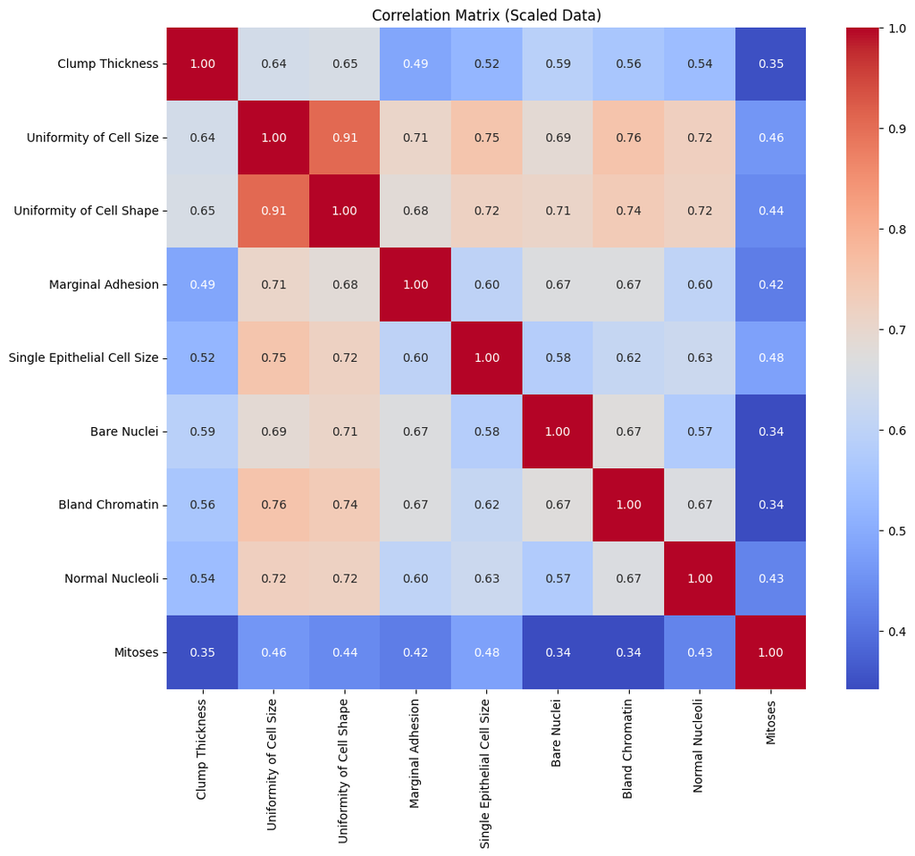

```python
plt.figure(figsize=(12, 10))
sns.heatmap(features_scaled_df.corr(), annot=True, fmt=".2f", cmap='coolwarm')
plt.title("Correlation Matrix (Scaled Data)")
plt.show()
```

## Insights Based on the Correlation Matrix

High Correlation with Class Label: Features such as `Uniformity of Cell Size` and `Uniformity of Cell Shape` showed strong positive correlations with the Class target variable. This indicates that as the values in these features increase, the likelihood of the class label being 4 (indicative of a more severe condition) also increases. These features are critical for predictive modeling as they significantly contribute to determining the class label.

Relationships Between Features: There was a notable correlation between Uniformity of Cell Size and Uniformity of Cell Shape, suggesting these features often increase together. Their similar behavior underscores their importance in analyzing cellular characteristics that contribute to the class label.

Correlation with Mitotic Activity: The feature Mitoses showed a correlation with the Class label, but it was generally lower than the correlation values of Uniformity of Cell Size and Uniformity of Cell Shape. This suggests that while mitotic activity is relevant, it may not be as strongly predictive of the class label 4 compared to the uniformity features.

Low Correlation Features: Some features might have shown lower correlation coefficients with the Class label, indicating that they have a weaker linear relationship with the outcome.

Multicollinearity Observation: The strong correlation between certain features, like Uniformity of Cell Size and Uniformity of Cell Shape, also points to multicollinearity.

## 4. Data Preparation

a. Do the final feature selection and extract them into Column X and the class label into Column into Y. b. Split the dataset into training and test sets.

#### Preventive Measures

- Since the number of unique `Sample code numbers` are high this was causing decision tree to exceed the maximum depth limit and so we dropped it from the dataset before training the model.

```python
# Excluding 'Sample code number' and using all other features for X, and 'Class' for Y
X = data.drop(['Sample code number', 'Class'], axis=1)
Y = data['Class']

X_scaled = scaler.fit_transform(X)

# Create a new DataFrame for the scaled data
# It's important to include the column names when reconstructing the DataFrame
data_scaled = pd.DataFrame(X_scaled, columns=X.columns)


# Splitting the dataset into training and test sets
X_train, X_test, Y_train, Y_test = train_test_split(X, Y, test_size=0.2, random_state=277)
```

## 5. Model Building [1 M]

a. Perform Model Development using logistic regression and decision tree, separately. Deep Learning Models are strictly not allowed.

b. Train the model and print the training accuracy and loss values.

```python
# Model building
# Logistic Regression
log_reg = LogisticRegression()
log_reg.fit(X_train, Y_train)
log_reg_train_acc = log_reg.score(X_train, Y_train)
log_reg_probs_train = log_reg.predict_proba(X_train)
log_regression_train_loss = log_loss(Y_train, log_reg_probs_train)

# Decision Tree Classifier
dtree = DecisionTreeClassifier()
dtree.fit(X_train, Y_train)
dtree_train_acc = dtree.score(X_train, Y_train)
dtree_probs = dtree.predict_proba(X_train)
dtree_test_loss = log_loss(Y_train, dtree_probs)

# Training accuracy for both models
print(f'Accuracy for Logistic regression is: {log_reg_train_acc}.')
print(f'Accuracy for Decision Tree is: {dtree_train_acc}.')
print(f'Loss Value for Logistic regression is: {log_regression_train_loss}.')
print(f'Loss Value for Decision Tree is: {dtree_test_loss}.')
```

```
Accuracy for Logistic regression is: 0.9677996422182469.
Accuracy for Decision Tree is: 1.0.
Loss Value for Logistic regression is: 0.08117201212358743.
Loss Value for Decision Tree is: 2.220446049250313e-16.
```

## 6. Performance Evaluation [4 M]

a. Print the confusion matrix. Provide appropriate analysis for the same.

b. Do the prediction for the test data and display the results for the inference.

```python
# Performance evaluation - Confusion Matrix and additional metrics
# Generating predictions
log_reg_preds = log_reg.predict(X_test)
dtree_preds = dtree.predict(X_test)

# Logistic Regression
log_reg_cm = confusion_matrix(Y_test, log_reg_preds)
log_reg_report = classification_report(Y_test, log_reg_preds)

# Decision Tree
dtree_cm = confusion_matrix(Y_test, dtree_preds)
dtree_report = classification_report(Y_test, dtree_preds)

# Confusion matrices
print("Logistic Regression Confusion Matrix:\n", log_reg_cm)
print("\nDecision Tree Confusion Matrix:\n", dtree_cm)

# Classification reports
print("\nLogistic Regression Classification Report:\n", log_reg_report)
print("\nDecision Tree Classification Report:\n", dtree_report)
```

```
Logistic Regression Confusion Matrix:
 [[89  2]
 [ 4 45]]

Decision Tree Confusion Matrix:
 [[89  2]
 [ 7 42]]

Logistic Regression Classification Report:
               precision    recall  f1-score   support

           2       0.96      0.98      0.97        91
           4       0.96      0.92      0.94        49

    accuracy                           0.96       140
   macro avg       0.96      0.95      0.95       140
weighted avg       0.96      0.96      0.96       140


Decision Tree Classification Report:
               precision    recall  f1-score   support

           2       0.93      0.98      0.95        91
           4       0.95      0.86      0.90        49

    accuracy                           0.94       140
   macro avg       0.94      0.92      0.93       140
weighted avg       0.94      0.94      0.93       140
```

## Performance Evaluation

Lets evaluate the performance of these models on the test set. The performance evaluation of both models on the test set provides the following insights:

### Logistic Regression

Confusion Matrix and Classification Report for Logistic Regression:

### Decision Tree

Confusion Matrix and Classification Report for Decision Tree:

### Analysis

In evaluating the performance of the Logistic Regression and Decision Tree models on the test set, it's crucial to consider the objectives outlined in the problem statement, particularly the emphasis on minimizing false negatives for label 4. While evaluating model performance, one might observe nuances in the performance metrics that influence the choice of model beyond mere accuracy.

#### Key Considerations:

- The choice between these models hinges on the critical examination of precision, recall, and the specific context of false negatives for label 4. The Logistic Regression model might be preferred if it provides a more favorable balance of these metrics concerning the project's goals. The importance of recall for label 4 in this scenario cannot be overstated. A model with a higher recall for label 4 is preferable in medical diagnostics, where failing to identify a severe condition could have dire consequences, even if it comes at the expense of a slight decrease in overall accuracy or precision for less severe conditions (label 2).
- Furthermore, Logistic Regression offers a level of interpretability regarding how each feature influences the likelihood of each class. This interpretability can be invaluable in healthcare settings, where understanding the influence of different factors on diagnostic outcomes is crucial.

### 1) Model Building

Build ML models using K-Nearest Neighbors (K-NN), Naive Bayesian, Random Forest, and Adaboost.

```python
# Building the K-NN model
knn = KNeighborsClassifier(n_neighbors=5)
knn.fit(X_train, Y_train)

# Predictions
knn_preds = knn.predict(X_test)

# Evaluation Metrics for K-NN
knn_accuracy = accuracy_score(Y_test, knn_preds)
knn_precision, knn_recall, knn_fscore, _ = precision_recall_fscore_support(Y_test, knn_preds, average='weighted')

print(f"K-NN Accuracy: {knn_accuracy}")
print(f"K-NN Precision: {knn_precision}")
print(f"K-NN Recall: {knn_recall}")
print(f"K-NN F-score: {knn_fscore}")
```

```
K-NN Accuracy: 0.9642857142857143
K-NN Precision: 0.9645555555555555
K-NN Recall: 0.9642857142857143
K-NN F-score: 0.9643674312182599
```

```python
# Naive Bayes model
nb = GaussianNB()
nb.fit(X_train, Y_train)

# Predictions
nb_preds = nb.predict(X_test)

# Evaluation Metrics for Naive Bayes
nb_accuracy = accuracy_score(Y_test, nb_preds)
nb_precision, nb_recall, nb_fscore, _ = precision_recall_fscore_support(Y_test, nb_preds, average='weighted')

print(f"Naive Bayes Accuracy: {nb_accuracy}")
print(f"Naive Bayes Precision: {nb_precision}")
print(f"Naive Bayes Recall: {nb_recall}")
print(f"Naive Bayes F-score: {nb_fscore}")
```

```
Naive Bayes Accuracy: 0.9571428571428572
Naive Bayes Precision: 0.9579422780348092
Naive Bayes Recall: 0.9571428571428572
Naive Bayes F-score: 0.9573333333333334
```

```python
# Random Forest model
rf = RandomForestClassifier(random_state = 277)
rf.fit(X_train, Y_train)

# Predictions
rf_preds = rf.predict(X_test)

# Evaluation Metrics for Random Forest
rf_accuracy = accuracy_score(Y_test, rf_preds)
rf_precision, rf_recall, rf_fscore, _ = precision_recall_fscore_support(Y_test, rf_preds, average='weighted')

print(f"Random Forest Accuracy: {rf_accuracy}")
print(f"Random Forest Precision: {rf_precision}")
print(f"Random Forest Recall: {rf_recall}")
print(f"Random Forest F-score: {rf_fscore}")
```

```
Random Forest Accuracy: 0.9642857142857143
Random Forest Precision: 0.9642210144927535
Random Forest Recall: 0.9642857142857143
Random Forest F-score: 0.9641992000450679
```

```python
# Adaboost model
ada = AdaBoostClassifier(algorithm='SAMME', random_state=277)
ada.fit(X_train, Y_train)

# Predictions
ada_preds = ada.predict(X_test)

# Evaluation Metrics for Adaboost
ada_accuracy = accuracy_score(Y_test, ada_preds)
ada_precision, ada_recall, ada_fscore, _ = precision_recall_fscore_support(Y_test, ada_preds, average='weighted')

print(f"Adaboost Accuracy: {ada_accuracy}")
print(f"Adaboost Precision: {ada_precision}")
print(f"Adaboost Recall: {ada_recall}")
print(f"Adaboost F-score: {ada_fscore}")
```

```
Adaboost Accuracy: 0.9285714285714286
Adaboost Precision: 0.9282772820864791
Adaboost Recall: 0.9285714285714286
Adaboost F-score: 0.9282155797101449
```

```python
# Parameter grid for Grid search
param_grid = {
    'n_estimators': [100, 200],
    'max_depth': [None, 10, 20],
    'min_samples_split': [2, 5],
}

# Grid search
grid_search = GridSearchCV(estimator=RandomForestClassifier(random_state=277), param_grid=param_grid, cv=5, scoring='accuracy')
grid_search.fit(X_train, Y_train)

# Best parameters and score
print("Grid Search Best parameters:", f'Min Sample Split: {grid_search.best_params_['min_samples_split']}')
print("Grid Search Best parameters:", f'Min Sample Split: {grid_search.best_params_['min_samples_split']}')
print("Grid Search Best parameters:", f'N Estimators: {grid_search.best_params_['n_estimators']}')
print("Grid Search Best score:", grid_search.best_score_)
```

```
Grid Search Best parameters: Min Sample Split: 5
Grid Search Best parameters: Min Sample Split: 5
Grid Search Best parameters: N Estimators: 100
Grid Search Best score: 0.9696106821106822
```

### Model Performance Conclusions

#### K-Nearest Neighbors (K-NN)

##### Accuracy:

96.43% - This indicates that K-NN correctly predicts 96.43% of the labels. It's a high score, suggesting strong performance.

##### Precision:

96.46% - Precision measures the accuracy of positive predictions. This high precision indicates a low false positive rate.

##### Recall:

96.43% - Recall (or sensitivity) measures the ability of the model to find all the positive samples. The high recall score suggests K-NN is effective in identifying most positive instances.

##### F-score: 96.44% -

The F-score is the harmonic mean of precision and recall, indicating a balance between them. A high F-score suggests both high precision and recall.

#### Naive Bayes

##### Accuracy:

95.71% - Slightly lower than K-NN but still indicates good performance.

##### Precision:

95.79% - Indicates a relatively low false positive rate, though slightly lower than K-NN.

##### Recall:

95.71% - Shows good ability to identify positive instances, but marginally less effective than K-NN.

##### F-score:

95.73% - Indicates a balance between precision and recall, though slightly lower than K-NN.

#### Random Forest

##### Accuracy:

96.43% - Equal to K-NN, indicating a high overall prediction correctness.

##### Precision:

96.42% - Comparable to K-NN, indicating a low rate of false positives.

##### Recall:

96.43% - Equal to its accuracy, showing excellent capability in identifying positive samples.

##### F-score:

96.42% - Indicates a strong balance between precision and recall, comparable to K-NN.

#### Adaboost

##### Accuracy:

92.86% - The lowest among the models, suggesting it's less effective at predictions in this context.

##### Precision:

92.83% - Indicates a higher false positive rate compared to other models.

##### Recall:

92.86% - Shows it's less capable of identifying all positive instances.

##### F-score:

92.82% - Reflects a balance between precision and recall but is lower than other models, suggesting less effectiveness.

#### Grid Search Best Score for Random Forest

The grid search results for Random Forest suggest that allowing the trees to grow without depth restrictions (Max Depth: None) and choosing a relatively small minimum number of samples required to split an internal node (Min Samples Split: 5) with 100 estimators leads to the best performance. The best score from the grid search is slightly higher than the initial Random Forest evaluation, indicating that tuning the hyperparameters has improved model performance.

#### Conclusion

Random Forest and K-NN show the strongest performances among the tested models, making them both excellent choices for this classification task.

Naive Bayes performs well, especially considering its simplicity and the assumption of feature independence, which might not hold true in all cases.

Adaboost shows good but not exceptional performance, suggesting there might be better choices for this specific dataset.

The choice of model should consider not just these metrics but also factors like model complexity, interpretability, and computational efficiency.

Random Forest, with its robust performance and flexibility, could be considered the best model if these factors are less of a concern. However, K-NN's simplicity and effectiveness make it a strong contender, especially in scenarios where model transparency and interpretability are more critical.

```python
# Fine Tuning

# KNN
knn_param_grid = {
    'n_neighbors': [3, 5, 7, 9],
    'weights': ['uniform', 'distance'],
}

# Initialize the classifier
knn = KNeighborsClassifier()

# Initialize GridSearchCV
knn_grid_search = GridSearchCV(knn, knn_param_grid, cv=5, scoring='accuracy', n_jobs=-1)

# Fit GridSearchCV
knn_grid_search.fit(X_train, Y_train)

# Best parameters and score
print("K-NN Best parameters:", knn_grid_search.best_params_)
print("K-NN Best score:", knn_grid_search.best_score_)
print()

nb_param_grid = {
    'var_smoothing': np.logspace(0,-9, num=100)
}

nb = GaussianNB()

# Since GaussianNB doesn't have meaningful hyperparameters to tune in this way, this step is more illustrative
nb_grid_search = GridSearchCV(nb, nb_param_grid, cv=5, scoring='accuracy', n_jobs=-1)
nb_grid_search.fit(X_train, Y_train)

print("Naive Bayes Best parameters:", nb_grid_search.best_params_)
print("Naive Bayes Best score:", nb_grid_search.best_score_)
print()
rf_param_grid = {
    'n_estimators': [100, 200, 500],
    'max_depth': [None, 10, 20, 30],
    'min_samples_split': [2, 5, 10],
    'min_samples_leaf': [1, 2, 4],
}

# Initialize the classifier
rf = RandomForestClassifier(random_state=277)

# Initialize GridSearchCV
rf_grid_search = GridSearchCV(rf, rf_param_grid, cv=5, scoring='accuracy', n_jobs=-1)

# Fit GridSearchCV
rf_grid_search.fit(X_train, Y_train)

# Best parameters and score
print("Random Forest Best parameters:", rf_grid_search.best_params_)
print("Random Forest Best score:", rf_grid_search.best_score_)
print()


# Define the parameter grid
adaboost_param_grid = {
    'n_estimators': [50, 100, 200],
    'learning_rate': [0.01, 0.1, 1],
}

# Initialize the classifier
adaboost = AdaBoostClassifier(algorithm='SAMME', random_state=277)

# Initialize GridSearchCV
adaboost_grid_search = GridSearchCV(adaboost, adaboost_param_grid, cv=5, scoring='accuracy', n_jobs=-1)

# Fit GridSearchCV
adaboost_grid_search.fit(X_train, Y_train)

# Best parameters and score
print("Adaboost Best parameters:", adaboost_grid_search.best_params_)
print("Adaboost Best score:", adaboost_grid_search.best_score_)
```

```
K-NN Best parameters: {'n_neighbors': 7, 'weights': 'uniform'}
K-NN Best score: 0.969610682110682

Naive Bayes Best parameters: {'var_smoothing': 0.12328467394420659}
Naive Bayes Best score: 0.9678571428571429

Random Forest Best parameters: {'max_depth': None, 'min_samples_leaf': 1, 'min_samples_split': 10, 'n_estimators': 100}
Random Forest Best score: 0.9714124839124839

Adaboost Best parameters: {'learning_rate': 0.1, 'n_estimators': 200}
Adaboost Best score: 0.9606660231660232
```

```python
# Common Util to evaluate model
def evaluate_model(y_true, y_preds, model_name):
    accuracy = accuracy_score(y_true, y_preds)
    precision, recall, fscore, _ = precision_recall_fscore_support(y_true, y_preds, average='weighted')
    misclassification_rate = 1 - accuracy
    print(f"{model_name} Performance after using best parameters:")
    print(f"Accuracy: {accuracy}")
    print(f"Precision: {precision}")
    print(f"Recall: {recall}")
    print(f"F-score: {fscore}")
    print(f"Misclassification Rate: {misclassification_rate}")
    print("\n")
```

```python
# K-NN - Re-train with best parameters
knn_optimized = KNeighborsClassifier(n_neighbors=7, weights='uniform')
knn_optimized.fit(X_train, Y_train)
knn_preds = knn_optimized.predict(X_test)
# Evaluation
evaluate_model(Y_test, knn_preds, "K-NN")
```

```
K-NN Performance after using best parameters:
Accuracy: 0.9642857142857143
Precision: 0.9642210144927535
Recall: 0.9642857142857143
F-score: 0.9641992000450679
Misclassification Rate: 0.0357142857142857
```

```python
# Naive Bayes - Re-train with best parameters
nb_optimized = GaussianNB(var_smoothing=0.12328467394420659)
nb_optimized.fit(X_train, Y_train)
nb_preds = nb_optimized.predict(X_test)

# Evaluation
evaluate_model(Y_test, nb_preds, "Naive Bayes")
```

```
Naive Bayes Performance after using best parameters:
Accuracy: 0.9571428571428572
Precision: 0.9571428571428572
Recall: 0.9571428571428572
F-score: 0.9571428571428572
Misclassification Rate: 0.042857142857142816
```

```python
# Random Forest - Re-train with best parameters
rf_optimized = RandomForestClassifier(max_depth=None, min_samples_leaf=1, min_samples_split=10, n_estimators=100, random_state=277)
rf_optimized.fit(X_train, Y_train)
rf_preds = rf_optimized.predict(X_test)

# Evaluation
evaluate_model(Y_test, rf_preds, "Random Forest")
```

```
Random Forest Performance after using best parameters:
Accuracy: 0.9571428571428572
Precision: 0.9571428571428572
Recall: 0.9571428571428572
F-score: 0.9571428571428572
Misclassification Rate: 0.042857142857142816
```

```python
# Re-train with best parameters
adaboost_optimized = AdaBoostClassifier(algorithm = 'SAMME', learning_rate=0.1, n_estimators=200, random_state=277)
adaboost_optimized.fit(X_train, Y_train)
adaboost_preds = adaboost_optimized.predict(X_test)

# Evaluation
evaluate_model(Y_test, adaboost_preds, "Adaboost")
```

```
Adaboost Performance after using best parameters:
Accuracy: 0.9357142857142857
Precision: 0.9366950757575759
Recall: 0.9357142857142857
F-score: 0.9348456097981714
Misclassification Rate: 0.06428571428571428
```

## Analysis

K-NN achieves the highest accuracy, precision, recall, and F-score among all models tested. Its balanced performance across all metrics suggests it is highly effective at correctly classifying the test data, with a good balance between sensitivity and specificity. The misclassification rate is the lowest, making it the most reliable model in this comparison.

Naive Bayes and Random Forest show identical performance metrics in this round of evaluation. Both models offer solid accuracy, precision, recall, and F-score, indicating they are competent at handling the classification task. However, their slightly higher misclassification rate compared to K-NN suggests they may not be as consistent in correctly predicting all classes.

Adaboost shows the lowest accuracy and the highest misclassification rate among the models. Despite having reasonable precision and recall values, its overall performance is slightly lower, indicating it may struggle more with this particular dataset.

### Recommendation

Given the evaluation metrics, K-Nearest Neighbors (K-NN) is recommended as the most favorable model for this dataset. The justification for this choice includes:

##### Highest Accuracy and Lowest Misclassification Rate:

K-NN not only achieves the highest accuracy, meaning it correctly classifies a higher percentage of instances than the other models, but it also has the lowest misclassification rate, indicating fewer errors in prediction.

#### Balance Between Precision and Recall:

K-NN maintains a high level of precision and recall, indicating it is effective at minimizing both false positives and false negatives. This balance is crucial in many applications, especially if the cost of false positives and negatives is high.

#### Consistent F-score:

The high F-score of K-NN suggests a balanced harmonic mean of precision and recall, further indicating its effectiveness at classifying instances correctly across all classes.

While K-NN's performance is superior in this analysis, it's important to consider the specific requirements and constraints of the application for which the model is intended. Factors such as interpretability, computational efficiency, and the nature of the data (e.g., its dimensionality and the presence of noisy features) may influence the final model choice. However, based solely on the performance metrics provided, K-NN demonstrates the most favorable performance for this dataset and problem statement.